# Report of Assignment 3

Zhen Huang

4/29/2020

### 1. Candidate Models

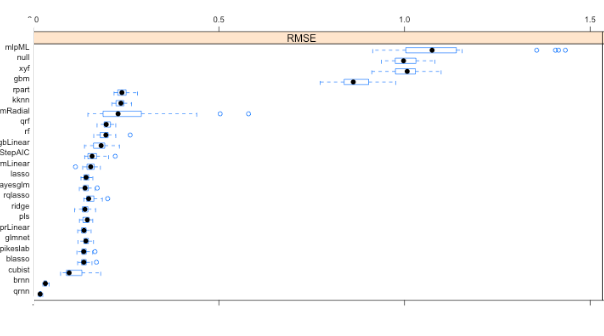

RMSE of candidate models

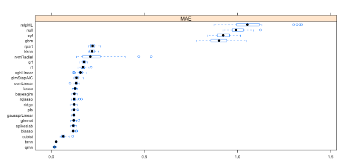

MAE of candidate models

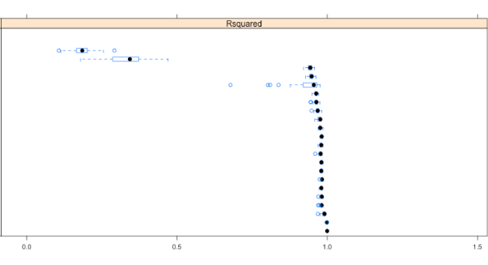

Rsquared of candidate models

#### 1.1 Table of candidate models

| Choices | Model | Pre-processing | RMSE | Hyperparameters | Training Time | Comments |
| --- | --- | --- | --- | --- | --- | --- |
| *Best candidate model | qrnn | “bagimpute”,“center”,“scale”,“dummy” | 12.39 | n.hidden=3, penalty=0 and bag=FALSE | 1412.66 sec |  |
|  | brnn | “bagimpute”,“center”,“scale”,“dummy” | 21.31 | neurons=4 | 349.26 sec |  |
|  | cubist | “bagimpute”,“dummy” | 68.57 | committees=81, neighbors=5 | 340.89 sec |  |
|  | gaussprLinear | “bagimpute”,“center”,“scale”,“pca”,“dummy” | 85.35 | No hyperparameter | 35.23 sec |  |
| Trained after finding brnn | blasso | “knnimpute”,“center”,“scale”,“dummy” | 87.54 | sparsity=0.29 | 44.89 sec |  |
| Trained after finding brnn | bayesglm | “knnimpute”,“center”,“scale”,“dummy” | 91.37 | No hyperparameter | 42.64 sec |  |
| Trained after finding qrnn | spikeslab | “knnimpute”,“center”,“scale”,“dummy” | 87.86 | vars=16 | 59.31 sec |  |
| Trained after finding qrnn | rqlasso | “knnimpute”,“center”,“scale”,“dummy” | 93.17 | lambda=0.01 | 307.61 sec |  |
| Supplied | GLMnet | “bagimpute”,“Yeojohnson”,“dummy”,“center”,“scale” | 90.58 | alpha=0.99, lambda=2.97 | 341.07s | edge of the grid |
| Supplied | PLS | “bagimpute”,“YeoJohnson”,“center”,“scale”,“dummy” | 90.73 | ncomp 13 | 118.49 sec | About ten times long to use bagimpute instead of knnimpute, slightly improve the model performance |
|  | kernelpls | “knnimpute”,“center”,“scale” | 95.94 | ncomp=12 | 136.75 sec |  |
| Supplied | Rpart | “center”,“scale” | 152.68 |  | Normalise could improve predict accuracy |  |
|  | rf | “knnimpute” | 124.80 | mtry 14 | 55.22 sec |  |
|  | lasso | “bagimpute”,“Yeojohnson”,“center”,“scale”,“dummy” | 90.36 | fraction=0.79 | 63.66 sec |  |
|  | ridge | “bagimpute”,“Yeojohnson”,“center”,“scale”,“dummy” | 89.45 | lambda=0.01056009 | 150.89 sec |  |
|  | xgbLinear | “knnimpute” | 114.77 | 119.05 sec |  |  |
|  | glmboost | “knnimpute”,“dummy” | 94.44 | mstop=532 and prune=yes | 78.09 sec |  |
|  | glmStepAIC | “knnimpute”,“center”,“scale”,“dummy” | 103.34 | No hyperparameter | 11.57 sec |  |
|  | svmLinear | “knnimpute”,“center”,“scale”,“dummy” | 98.49 | C=0.07086818 | 254.67 sec | edge of the grid |
|  | rvmRadial | “knnimpute”,“center”,“scale”,“dummy” | 169.75 | sigma=0.005040349 | 122.23 sec | Normalisation can siginificantly improve the method fitting |
|  | kknn | “knnimpute”,“pca”,“dummy” | 150.02 | kmax=51, distance=1.006154 and kernel=inv | 34.66 sec |  |
|  | gbm | “knnimpute”,“center”,“scale”,“dummy” | shrinkage=0.33, interaction.depth=1, n.minobsinnode=20, n.trees=321 | 550.26 | 114.77 sec |  |
|  | xyf | “knnimpute”,“dummy” | 702.31 | xdim=3, ydim=14, user.weights=0.875 and topo=rectangular | 30.25 sec | Not tolerant missing values |
|  | mlpKerasDropout | “knnimpute”,“dummy” | 680.52 | 75.25 sec | Not tolerant missing values |  |
|  | mlpML | “knnimpute”,“dummy” | 702.31 | layer1=2, layer2=5 and layer3=0 | 49.02 sec | Not tolerant missing values |
|  | pcaNNet | “knnimpute”,“dummy” | 702.31 | size=4 and decay=3.743782e-05 | 49.02 sec | Not tolerant missing values |

### 2. The Best model and the other top models

Assume “best” means “minimum RMSE”, the `qrnn` model performed better than any other candidate models, which had RMSE=12.39 from resampled performance validation. The screenshot below shows that `qrnn` had significantly good performance in terms of metrics without any overlap with the other models in candidate model group.

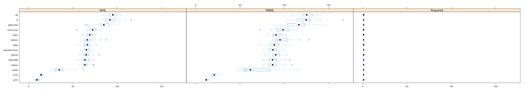

Model selection

Below are the statistics and visualisation for the best performing model based on test data.

```
Unseen data results for chosen model: qrnn
     RMSE  Rsquared       MAE
9.1621685 0.9997505 6.5061448
```

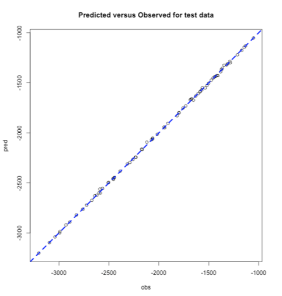

Screenshot of qrnn predicted test data

- **an explanation on how the best model works - do some research on your best performing method and hypothesize why it suits the data so well.**

**Answer:** Quantile regression neural network, `qrnn`, which were met luckly in this assignment, has some feature to significatly may improve its performance in this data set.

**Answer:** `cubist` would be the optimum medel if transparency are taken into account. As the sceenshot shows below, a tree-base structure of model may show the best split of each node. `rf` (random forest) also performed well in the test date set, the method also demestrated the features which are more important (Bloodtype). There is another finding that `rf` methods could have more accurate estimated RMSE by implement `oob` resampling method.

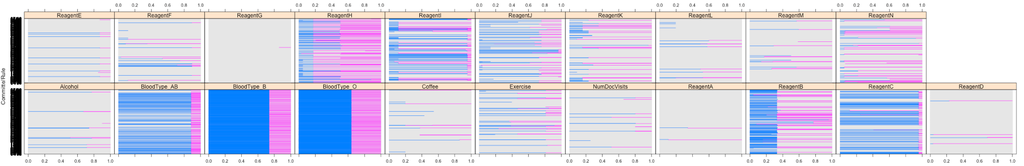

Variables splits in cubist model

```
Unseen data results for chosen model: cubist
      RMSE   Rsquared        MAE
23.6221164  0.9984519 10.1285528
```

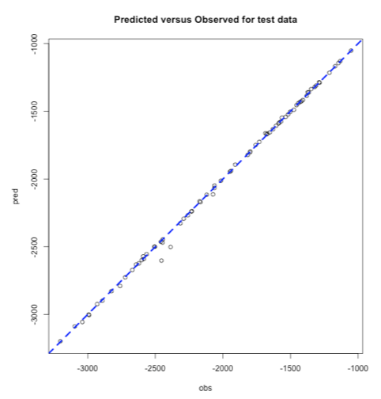

- **whether you recommend utilising an ensemble of some of the top models and why?**

**Answer:** I would not recommend utilising an ensemble of top models in the group for three reasons.

1. Ensembling lower performance model with a high model would not improve the final performance. Here `qrnn` and the rest of the top models had a gap in terms of performance metrics. So, we may not get better result than just using single `qrnn`
2. `qrnn` or `brnn` are both neural network mothods, which means they are already very complex models. If they are ensembled, we are running the risk of overfitting the model.
3. The rest of the top models had related predict results (or similar method to each other), such as blasso and ridge, glmnet and gaussprLinear. Similar methods or methods which have correlated results may not improve the final predict accuracy when they are ensembled.

Below are some test code to ensemble `blasso` and `spikeslab`.

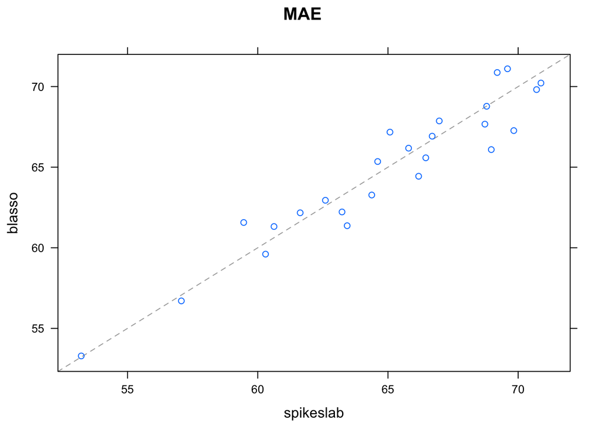

```r
xyplot(resamples(model_list))
```

```r
modelCor(resamples(model_list))
```

```
##              blasso spikeslab
## blasso    1.0000000 0.9539384
## spikeslab 0.9539384 1.0000000
```

```r
greedy_ensemble <- caretEnsemble(
  model_list,
  metric="RMSE",
  trControl=getTrControl())
summary(greedy_ensemble)
```

```
## The following models were ensembled: blasso, spikeslab
## They were weighted:
## -0.2998 0.3749 0.625
## The resulting RMSE is: 93.8372
## The fit for each individual model on the RMSE is:
##     method     RMSE   RMSESD
##     blasso 90.07215 8.541894
##  spikeslab 89.88570 7.879607
```

### 3. Explore the data set and pre-process steps with supplied methods

#### 3.1 Data types

The target data set has 380 observations and 20 variables. ‘Y’ is the output variable with numeric (real) and continues negative values. So it suggested this is a regression problem.

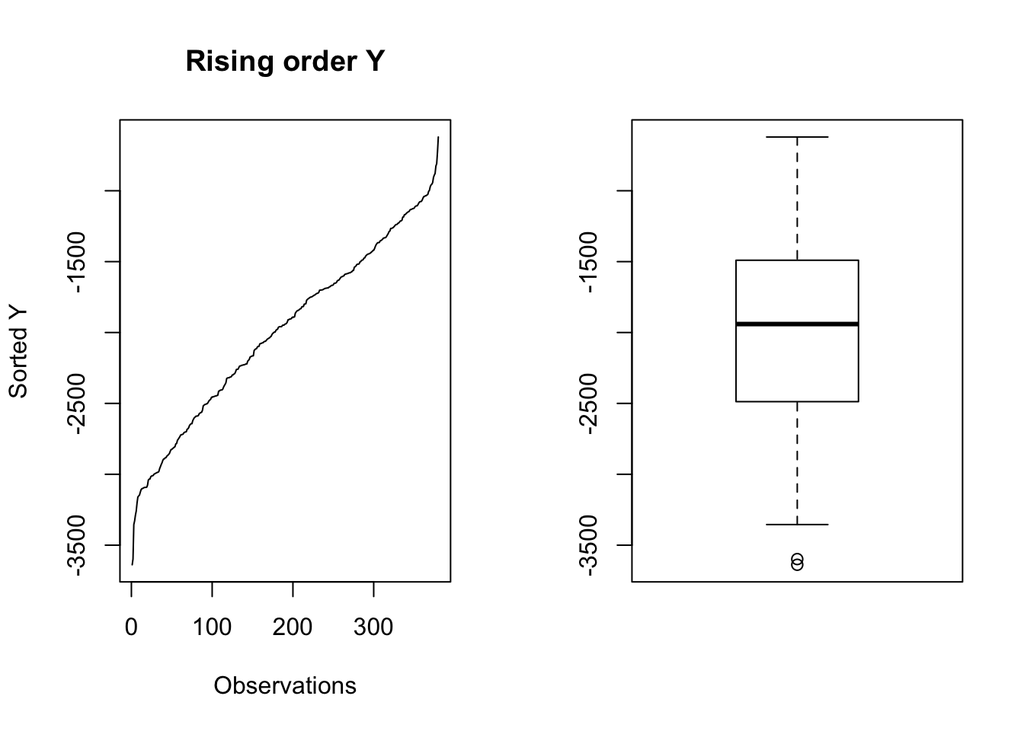

```r
my_data <-  read.csv(file = "Ass3Data.csv", row.names = "ID")
par(mfrow=c(1,2))
plot(sort(my_data$Y), type = 'l', main="Rising order Y", xlab="Observations", ylab="Sorted Y")
boxplot(my_data$Y, outline = TRUE, range = 1)
```

There are 19 variables predictors. The variable “BloodType” is a factor with four levels. The rest of the predictors are numeric.

#### 3.3 Data roles

The observation identifier,“ID”, was loaded as row.names of dataframes, which is 100% unique. “BloodType” could be a potential observation stratifier. The counts of each bloodtype are showed below.

```r
table(my_data$BloodType)
```

```
##
##   A  AB   B   O
##  94  49 101 136
```

Uncorrelated (or very weak) predictors are “Alchole”, “Coffee”, “Excercise” and “NumDocVisits”, and the other numeric predictors can also have implicit data roles, such as case weights, we may explore in the following steps.

#### 3.4 Pre-process steps

Started from keeping all the default setting in the supplied method. The ’Null Model" showed RMSE 640.30, which was the lowest criterion of methods performance. Using 80/20 train/test data set splitting, then following a general suggestion of pre-processing [Ordering of Steps](https://tidymodels.github.io/recipes/articles/Ordering.html). The supplied steps in the example code were added into the suggested `recipe` steps for better understanding. 1. Impute knnimpute, bagimpute, medianimpute (naomit instead of imputing) 2. Individual transformations for skewness and other issues YeoJohnson, poly 3. Discretize Not using in supplied steps 4. Create dummy variables dummy 5. Create interactions Not using in supplied steps 6. Normalization steps center, scale 7. Multivariate transformation pca, pls, ica (also kpca, isomap)

Two steps `step_poly` (also `step_ns`) are not used in example, but may be used to replaced a variable with new one for fitting a non-linear model. Filters, such as `step_nzv` and `step_corr` are not showed in above list, but would be tried later. All the `step_` functions are listed out on [Reference](https://tidymodels.github.io/recipes/reference/index.html)

| Choice | Model | Pre-processing | RMSE | Hyperparameters | Training Time | Comments |
| --- | --- | --- | --- | --- | --- | --- |
| Supplied | GLMnet | “bagimpute”,“Yeojohnson”,“dummy”,“center”,“scale” | 90.58 | alpha = 0.99, lambda = 2.97 | 341.07s | edge of the grid |
| Supplied | PLS | “bagimpute”,“YeoJohnson”,“center”,“scale”,“dummy” | 90.73 | ncomp 13 | 118.49 sec | About ten times long to use bagimpute instead of knnimpute, slightly improve the model performance |
|  | kernelpls | “knnimpute”,“center”,“scale” | 95.94 | 136.75 sec |  |  |
| Supplied | Rpart | “center”,“scale” | 152.68 |  | Normalise could improve predict accuracy |  |

#### 4. Finding candidate models

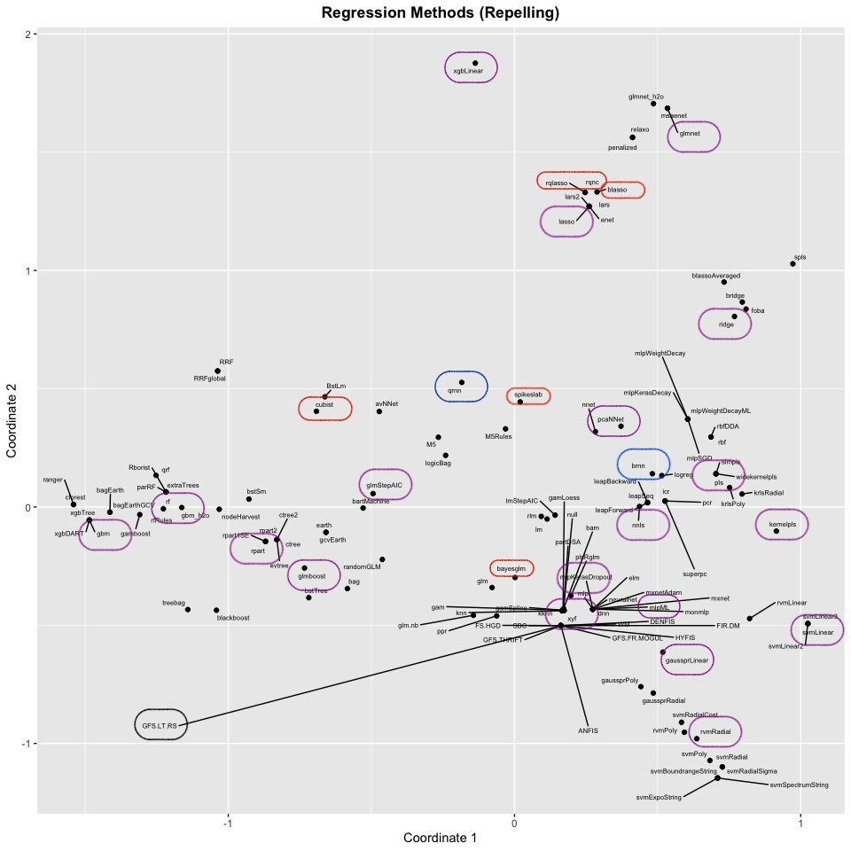

##### 4.1 Supplied methods

##### GLMnet (grid edge)

After implementing the choosen pre-processing steps, GLMnet got the lower metrics. While two hyper parameters alpha 0.99 and lambda 2.97 were on the edge of the `random` search.

**Result:**

- RMSE 90.58
- Hyper parameter:
  - alpha = 0.99, lambda = 2.97

**Pre-process**

| Choice | Model | Pre-processing | RMSE | Time | Comments |
| --- | --- | --- | --- | --- | --- |
|  | GLMnet | “naomit”,“dummy” | 250675.90 |  | default setting, worse than Null model |
|  | GLMnet | “knnimpute”,“dummy” | 98.39 |  | “medianimpute” had similar performances, “bagimpute” performaned a bit better but more time-consuming |
|  | GLMnet | “knnimpute”,“dummy”,“center”,“scale” | 93.73 | 57s | Standardise and Normalise numeric predictors expected to improve the performance |
|  | GLMnet | “knnimpute”,“Yeojohnson”,“dummy”,“center”,“scale”,“pca” | 365.70 |  | GLMnet Implicits feature selection, so pca did not improve the model performance |
|  | GLMnet | “knnimpute”,“Yeojohnson”,“dummy”,“center”,“scale”,“pls” | 95.02 |  | similar situation with “pca” |
|  | GLMnet | “knnimpute”,“Yeojohnson”,“dummy”,“center”,“scale”,“ica” | 503.54 |  | similar situation with “pca” |
| * | GLMnet | “bagimpute”,“Yeojohnson”,“dummy”,“center”,“scale” | 90.58 | 341.07s | Candidate GLMnet Model |

##### PLS

Compare with PCR, PLS took outcome variable into account, which do improve the model performance in terms of RMSE.

**Result:**

- RMSE 90.73
- Hyper parameter:
  - ncomp 13

**Pre-process**

| Choice | Model | Pre-processing | RMSE | Time | Comments |
| --- | --- | --- | --- | --- | --- |
|  | PLS | “knnimpute”,“dummy” | 142.36 | 8.26s |  |
|  | PLS | “knnimpute”,“YeoJohnson”,“center”,“scale”,"“dummy”" | 96.42 | 8.26 sec | PLS also prefers numeric values to be normal distributed |
| * | PLS | “bagimpute”,“YeoJohnson”,“center”,“scale”,“dummy” | 90.73 | 118.49 sec | About tem times long to use bagimpute instead of knnimpute, slightly improve the model performance |

#### Rpart (grid edge, case weight?)

**Pre-process**

| Choice | Model | Pre-processing | RMSE | Time | Comments |
| --- | --- | --- | --- | --- | --- |
|  | Rpart |  | 160.49 |  | initial setting |
|  | Rpart | “center”,“scale” | 152.68 |  | Normalise could improve predict accuracy |

##### 4.2 Extended methods

##### lasso

With experience in assiagnment 2, the pre-processing steps should be similar like GLMnet. The result proved this judgement.

**Result:**

- RMSE 90.36
- Hyper parameter:
  - fraction 0.79

**Pre-process**

| Choice | Model | Pre-processing | RMSE | Time | Comments |
| --- | --- | --- | --- | --- | --- |
| * | lasso | “bagimpute”,“Yeojohnson”,“center”,“scale”,“dummy” | 90.36 | 63.66 sec |  |
|  | lasso | “bagimpute”,“center”,“scale”,“dummy” | 90.92 | 72.63 sec |  |

##### ridge

**Result:**

- RMSE 89.45
- Hyper parameter:
  - lambda = 0.01056009

**Pre-process**

| Choice | Model | Pre-processing | RMSE | Time | Comments |
| --- | --- | --- | --- | --- | --- |
| * | ridge | “bagimpute”,“Yeojohnson”,“center”,“scale”,“dummy” | 89.45 | 150.89 sec |  |

##### kernelpls

**Result:**

**Pre-process**

| Choice | Model | Pre-processing | RMSE | Time | Comments |
| --- | --- | --- | --- | --- | --- |
|  | kernelpls | “knnimpute” | 184.03 | 178.69 sec |  |
| * | kernelpls | “knnimpute”,“center”,“scale” | 95.94 | 136.75 sec |  |
|  | kernelpls | “knnimpute”,“center”,“scale”,“dummy” | 95.87 | 136.75 sec | dummy had no significatn effect |

##### rf (Random Forest)

There is only one tuning hyper parameter `mtry` of `rf` in `caret`, the other `ntree` is set default 500. The method does not tolerant missing values, so “knnimpute” was set as default. Using out of bag instead of bootstrap to be the validation method can improve the model preformance. (Result was recorded below, but trainControl() was not modified in the final shiny app for a consistency of model selection) Tree-base methods may not predict accurate in regression problem, but they do offer insight of the importance of variables.

**Result:**

**Pre-process**

| Choice | Model | Pre-processing | RMSE | Time | Comments |
| --- | --- | --- | --- | --- | --- |
| * | rf | “knnimpute” | 124.80 | 55.22 sec |  |
|  | rf | “knnimpute”,“center”,“scale” | 124.60 | 102.22 sec | Normalise did not improve random forest |
|  | rf | “knnimpute”,“center”,“scale” | 115.32 | 102.22 sec | “oob” resample method improve rf method |

##### xgbLinear ()

The method are not tolerant to missing value and norminal variables, so “knnimpute” and “dummy” were the initial pre-process steps.

**Result:**

- RMSE 114.77
- Hyper parameter:
  - nrounds = 60, lambda = 0.251548, alpha = 0.0002734832, eta = 1.294612.

**Pre-process**

| Choice | Model | Pre-processing | RMSE | Time | Comments |
| --- | --- | --- | --- | --- | --- |
|  | xgbLinear | “knnimpute” | 114.77 | 119.05 sec |  |

##### gbm

**Result:**

- RMSE 550.26
- Hyper parameter:
  - shrinkage = 0.33, interaction.depth = 1, n.minobsinnode = 20, n.trees = 321

**Pre-process**

| Choice | Model | Pre-processing | RMSE | Time | Comments |
| --- | --- | --- | --- | --- | --- |
|  | gbm |  | 556.26 | 163.29 sec |  |
|  | gbm | “knnimpute”,“center”,“scale” | 551.30 | 144.25 sec |  |
|  | gbm | “knnimpute”,“center”,“scale”,“dummy” | 550.26 | 114.77 sec |  |

##### glmboost mboost

**Result:**

- RMSE 94.44
- Hyper parameter:
  - mstop = 532 and prune = yes

**Pre-process**

| Choice | Model | Pre-processing | RMSE | Time | Comments |
| --- | --- | --- | --- | --- | --- |
|  | glmboost |  | 556.26 | 163.29 sec |  |
| * | glmboost | “knnimpute”,“dummy” | 94.44 | 78.09 sec |  |
|  | glmboost | “knnimpute”,“center”,“scale”,“pls”,“dummy” | 95.53 | 106.22 sec |  |

##### svmLinear kernlab (grid edge)

**Result:**

- RMSE 98.49
- Hyper parameter:
  - C = 0.07086818

**Pre-process**

| Choice | Model | Pre-processing | RMSE | Time | Comments |
| --- | --- | --- | --- | --- | --- |
|  | svmLinear | “knnimpute”,“dummy” | 99.00 | 116.53 sec | Not tolerant missing values |
| * | svmLinear | “knnimpute”,“center”,“scale”,“dummy” | 98.49 | 254.67 sec |  |
|  | svmLinear | “knnimpute”,“center”,“scale”,“pls”,“dummy” | 101.79 | 246.42 sec |  |

##### glmStepAIC (MASS)

**Result:**

**Pre-process**

| Choice | Model | Pre-processing | RMSE | Time | Comments |
| --- | --- | --- | --- | --- | --- |
|  | glmStepAIC | “knnimpute”,“dummy” | 103.44 | 52.23 sec | Not tolerant missing values |
| * | glmStepAIC | “knnimpute”,“center”,“scale”,“dummy” | 103.34 | 11.57 sec |  |

##### rvmRadial (kernlab)

**Result:**

- RMSE 169.75
- Hyper parameter:
  - sigma = 0.005040349

**Pre-process**

| Choice | Model | Pre-processing | RMSE | Time | Comments |
| --- | --- | --- | --- | --- | --- |
|  | rvmRadial | “knnimpute”,“dummy” | 2091.18 | 52.23 sec | Not tolerant missing values |
| * | rvmRadial | “knnimpute”,“center”,“scale”,“dummy” | 169.75 | 122.23 sec | Normalisation can siginificantly improve the method fitting |

##### gaussprLinear (kernlab)

**Result:**

**Pre-process**

| Choice | Model | Pre-processing | RMSE | Time | Comments |
| --- | --- | --- | --- | --- | --- |
|  | gaussprLinear | “knnimpute”,“dummy” | 96.48 | 9.88 sec | Not tolerant missing values |
|  | gaussprLinear | “knnimpute”,“center”,“scale”,“dummy” | 92.68 | 9.91 sec |  |
|  | gaussprLinear | “bagimpute”,“center”,“scale”,“dummy” | 86.88 | 35.23 sec |  |
|  | gaussprLinear | “bagimpute”,“center”,“scale”,“pca”,“dummy” | 85.35 | 35.23 sec |  |

##### qrnn (qrnn)

- RMSE 12.39
- Hyper parameter:
  - n.hidden = 3, penalty = 0 and bag = FALSE

**Pre-process**

| Choice | Model | Pre-processing | RMSE | Time | Comments |
| --- | --- | --- | --- | --- | --- |
|  | qrnn | “knnimpute”,“dummy” | 30.08 | 1125.58 sec | Not tolerant missing values |
| * | qrnn | “bagimpute”,“center”,“scale”,“dummy” | 12.39 | 1412.66 sec |  |

##### brnn (brnn)

**Result:**

- RMSE 21.31
- Hyper parameter:
  - neurons = 4

**Pre-process**

| Choice | Model | Pre-processing | RMSE | Time | Comments |
| --- | --- | --- | --- | --- | --- |
|  | brnn | “knnimpute”,“dummy” | 40.48 | 94.52 sec | Not tolerant missing values |
|  | brnn | “knnimpute”,“YeoJohnson”,“dummy” | 33.82 | 34.66 sec |  |
|  | brnn | “knnimpute”,“center”,“scale”,“dummy” | 33.47 | 34.66 sec |  |
|  | brnn | “knnimpute”,“center”,“scale”,“pca”,“dummy” | 35.08 | 110.53 sec | Method has done regularization, so feature extraction did no improve here |
| * | brnn | “bagimpute”,“center”,“scale”,“dummy” | 21.31 | 349.26 sec |  |

##### kknn (kknn)

**Result:**

- RMSE 150.02
- Hyper parameter:
  - kmax = 51, distance = 1.006154 and kernel = inv

**Pre-process**

| Choice | Model | Pre-processing | RMSE | Time | Comments |
| --- | --- | --- | --- | --- | --- |
|  | kknn | “knnimpute”,“dummy” | 200.2 | 30.25 sec | Not tolerant missing values |
| * | kknn | “knnimpute”,“pca”,“dummy” | 150.02 | 34.66 sec |  |

##### xyf (kohonen)

**Result:**

- RMSE 702.31
- Hyper parameter:
  - xdim = 3, ydim = 14, user.weights = 0.8750179 and topo = rectangular

**Pre-process**

| Choice | Model | Pre-processing | RMSE | Time | Comments |
| --- | --- | --- | --- | --- | --- |
|  | xyf | “knnimpute”,“dummy” | 702.31 | 30.25 sec | Not tolerant missing values |

##### mlpKerasDropout (keras)

The mothod can work in test scripts, but not work in shiny. So only result recorded below.

**Result:**

- RMSE 680.52
- Hyper parameter:

**Pre-process**

| Choice | Model | Pre-processing | RMSE | Time | Comments |
| --- | --- | --- | --- | --- | --- |
|  | mlpKerasDropout | “knnimpute”,“dummy” | 680.52 | 75.25 sec | Not tolerant missing values |

##### mlpML (RSNNS)

**Result:**

- RMSE 702.31
- Hyper parameter:
  - layer1 = 2, layer2 = 5 and layer3 = 0

**Pre-process**

| Choice | Model | Pre-processing | RMSE | Time | Comments |
| --- | --- | --- | --- | --- | --- |
|  | mlpML | “knnimpute”,“dummy” | 702.31 | 49.02 sec | Not tolerant missing values |

##### pcaNNet (nnet)

**Result:**

- RMSE 702.31
- Hyper parameter:
  - size = 4 and decay = 3.743782e-05

**Pre-process**

| Choice | Model | Pre-processing | RMSE | Time | Comments |
| --- | --- | --- | --- | --- | --- |
|  | pcaNNet | “knnimpute”,“center”,“scale”,“dummy” | 2098.83 | 24.46 se | Standardise deteriorated the model performance |
|  | pcaNNet | “knnimpute”,“dummy” | 702.31 | 49.02 sec | Not tolerant missing values |

##### GFS.LT.RS (frbs)

Failed to fit the model, due to more than three hours run in Rstudio.

##### cubist (Cubist)

**Result:**

**Pre-process**

| Choice | Model | Pre-processing | RMSE | Time | Comments |
| --- | --- | --- | --- | --- | --- |
|  | cubist | “knnimpute”,“dummy” | 79.49 | 187.6 sec |  |
|  | cubist | “knnimpute”,“center”,“scale”,“dummy” | 86.7 | 176 sec | Normalise did not improve, but enlarge the RMSE |
| * | cubist | “bagimpute”,“dummy” | 68.57 | 340.89 sec |  |

##### spikeslab (spikeslab)

**Result:**

- RMSE 87.86
- Hyper parameter:
  - vars = 16

**Pre-process**

| Choice | Model | Pre-processing | RMSE | Time | Comments |
| --- | --- | --- | --- | --- | --- |
|  | spikeslab | “knnimpute”,“center”,“scale”,“dummy” | 87.86 | 59.31 sec |  |

##### bayesglm (arm)

**Result:**

- RMSE 91.37
- No hyper parameter

**Pre-process**

| Choice | Model | Pre-processing | RMSE | Time | Comments |
| --- | --- | --- | --- | --- | --- |
|  | bayesglm | “knnimpute”,“center”,“scale”,“dummy” | 91.37 |  | 42.64 sec |

##### rqlasso (rqPen)

**Result:**

- RMSE 93.17
- Hyper parameter:
  - lambda = 0.01

**Pre-process**

| Choice | Model | Pre-processing | RMSE | Time | Comments |
| --- | --- | --- | --- | --- | --- |
|  | rqlasso | “knnimpute”,“center”,“scale”,“dummy” | 93.17 | 307.61 sec |  |

##### blasso (monomvn)

**Result:**

- RMSE 87.54
- Hyper parameter:
  - sparsity = 0.29

**Pre-process**

| Choice | Model | Pre-processing | RMSE | Time | Comments |
| --- | --- | --- | --- | --- | --- |
|  | blasso | “knnimpute”,“center”,“scale”,“dummy” | 87.54 | 44.89 se |  |

### Additional readings:

[The Remote Sensing Model for Estimating Urban Impervious Surface Percentage Based on the Cubist Model Tree](http://www.dqxxkx.cn/article/2016/1560-8999/1560-8999-18-10-1399.shtml)

[A Brief Introduction to caretEnsemble](https://cran.r-project.org/web/packages/caretEnsemble/vignettes/caretEnsemble-intro.html)

[How to Build an Ensemble Of Machine Learning Algorithms in R](https://machinelearningmastery.com/machine-learning-ensembles-with-r/)

[First steps with Non-Linear Regression in R](https://datascienceplus.com/first-steps-with-non-linear-regression-in-r/)

[Second steps with Non-Linear Regression in R](https://datascienceplus.com/second-step-with-non-linear-regression-adding-predictors/)